# Statistical Tests I

# Agenda

- Confidence Intervals
- Hypothesis Testing

# Learning objectives

By the end of the lecture, you will be able to …

- Use R to calculate confidence intervals for means and proportions
- Use R to conduct one and two sample t-tests

# Code-along 04

Download and open [code-along-04.qmd](https://www.dropbox.com/scl/fi/tbdcv6c51xrb9rzbtxplg/code-along-04.qmd?rlkey=gloziasukzc049vbwjus3ovmg&dl=1)

## Mini-task

Install the [`Rmisc()`](https://cran.r-project.org/web/packages/Rmisc/refman/Rmisc.html) package, available on CRAN.

**Run the code chunk in your code-along.**

*OR:* Copy and paste the code into your Console pane. Then hit “Enter”.

```r
install.packages("Rmisc")
```

We’ll use `Rmisc()` to calculate confidence intervals with `summarize()`.

## Mini-task

Load the standard packages and our new `Rmisc()` package.

```r
library(tidyverse)
library(haven) # not core tidyverse
library(gssr)
library(gssrdoc) # load the GSS codebook
library(summarytools)
library(Rmisc) # load the new package
```

## Mini-task

Load the 2022 GSS data.

```r
# Get the data from the 2022 survey
gss22 <- gss_get_yr(2022)
```

## Variables

- `wwwhr` Not counting e-mail, about how many minutes or hours per week do you use the Web?
- `postlife` Do you believe there is a life after death?
- `childs` How many children have you ever had?
- `sex` Respondent’s sex

## Mini-task

Create a dataset named `my_data` with the variables `wwwhr`, `postlife`, `childs`, & `sex` with no missing data

```r
# Create a new df
my_data <-gss22 |>
  select(wwwhr, postlife, childs, sex) |>
  drop_na()
```

# Confidence Intervals

## Review: `summarise()`

```r
my_data |>
  summarise(
    n = n(),
    mean = mean(wwwhr),
    sd = sd(wwwhr)
    )
```

```
# A tibble: 1 × 3
      n  mean    sd
  <int> <dbl> <dbl>
1   970  17.7  22.3
```

- CI
- SE

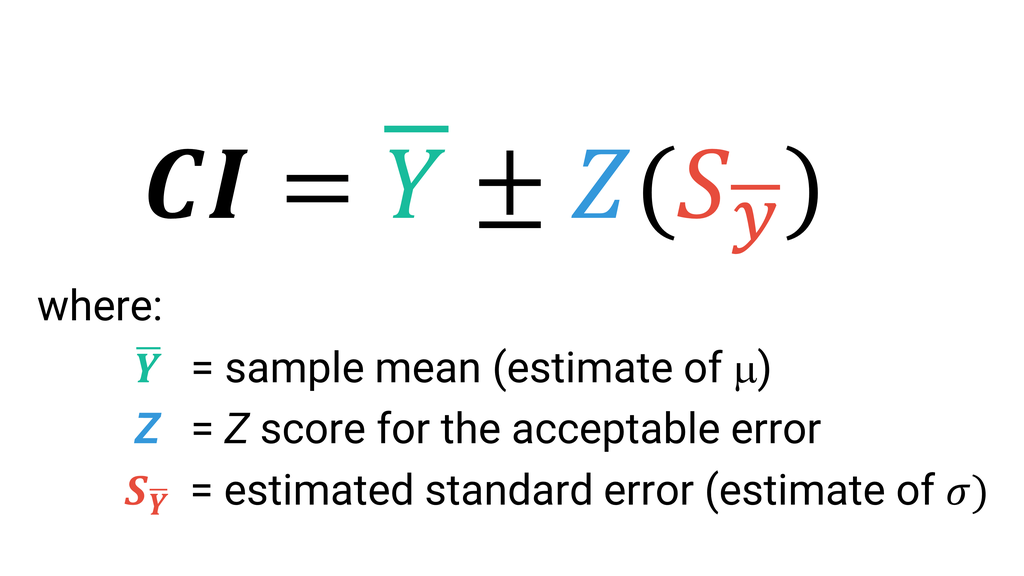

[figure not shown]

## `summarise()` with equation

```r
wwwhr_sum <- my_data |>
  summarise(
    n = n(),
    mean_wwwhr = mean(wwwhr),
    sd_wwwhr = sd(wwwhr),
    se_wwwhr = sd_wwwhr / sqrt(n),
    ci_lower = mean_wwwhr - (1.96 * se_wwwhr),
    ci_upper = mean_wwwhr + (1.96 * se_wwwhr)
    )
```

## Code Meets Question

What can we infer about the population mean based on this confidence interval?

```r
wwwhr_sum
```

```
# A tibble: 1 × 6
      n mean_wwwhr sd_wwwhr se_wwwhr ci_lower ci_upper
  <int>      <dbl>    <dbl>    <dbl>    <dbl>    <dbl>
1   970       17.7     22.3    0.716     16.3     19.1
```

## `summarise()` + `CI()`

```r
wwwhr_ci <- my_data |>
  summarise(
    n = n(),
    mean_wwwhr = mean(wwwhr),
    sd_wwwhr = sd(wwwhr),
    lowCI_wwwhr = Rmisc::CI(wwwhr)['lower'],
    hiCI_wwwhr  = Rmisc::CI(wwwhr)['upper']
    )

wwwhr_ci
```

```
# A tibble: 1 × 5
      n mean_wwwhr sd_wwwhr lowCI_wwwhr hiCI_wwwhr
  <int>      <dbl>    <dbl>       <dbl>      <dbl>
1   970       17.7     22.3        16.3       19.1
```

**Neat! But how confident are we?**

## `summarise()` + `CI()`

```r
wwwhr_ci99 <- my_data |>
  summarise(
    n = n(),
    mean_wwwhr = mean(wwwhr),
    sd_wwwhr = sd(wwwhr),
    lowCI_wwwhr = CI(wwwhr, ci = 0.99)['lower'],
    hiCI_wwwhr  = CI(wwwhr, ci = 0.99)['upper']
    )

wwwhr_ci99
```

```
# A tibble: 1 × 5
      n mean_wwwhr sd_wwwhr lowCI_wwwhr hiCI_wwwhr
  <int>      <dbl>    <dbl>       <dbl>      <dbl>
1   970       17.7     22.3        15.8       19.5
```

## CIs & percision

**95% confidence intervals**

```r
wwwhr_ci
```

```
# A tibble: 1 × 5
      n mean_wwwhr sd_wwwhr lowCI_wwwhr hiCI_wwwhr
  <int>      <dbl>    <dbl>       <dbl>      <dbl>
1   970       17.7     22.3        16.3       19.1
```

**99% confidence intervals**

```r
wwwhr_ci99
```

```
# A tibble: 1 × 5
      n mean_wwwhr sd_wwwhr lowCI_wwwhr hiCI_wwwhr
  <int>      <dbl>    <dbl>       <dbl>      <dbl>
1   970       17.7     22.3        15.8       19.5
```

**How does a 95% confidence interval differ from a 99% confidence interval in terms of width and certainty?**

## CIs (wrong) with proportions

```r
my_data |>
  summarise(
    n = n(),
    mean_ghosts = mean(postlife),
    sd_ghosts = sd(postlife),
    lowCI_ghosts = CI(postlife, ci = 0.99)['lower'],
    hiCI_ghosts  = CI(postlife, ci = 0.99)['upper']
    )
```

```
# A tibble: 1 × 5
      n mean_ghosts sd_ghosts lowCI_ghosts hiCI_ghosts
  <int>       <dbl>     <dbl>        <dbl>       <dbl>
1   970        1.19     0.389         1.15        1.22
```

**This doesn’t work because the values aren’t coded 0 and 1.**

`postlife` Do you believe there is a life after death?

## CIs (correct) with proportions

```r
# Use logic to recode (yes: 1 = 1; no: 2 = 0)
my_data$ghosts <- ifelse(my_data$postlife == 1, 1, 0)

my_data |>
  summarise(
    n = n(),
    mean_ghosts = mean(ghosts),
    sd_ghosts = sd(ghosts),
    lowCI_ghosts = CI(ghosts, ci = 0.99)['lower'],
    hiCI_ghosts  = CI(ghosts, ci = 0.99)['upper']
    )
```

```
# A tibble: 1 × 5
      n mean_ghosts sd_ghosts lowCI_ghosts hiCI_ghosts
  <int>       <dbl>     <dbl>        <dbl>       <dbl>
1   970       0.814     0.389        0.782       0.847
```

## Comparing CIs

- Code
- Table
- Plot

```r
my_data$sex <- zap_missing(my_data$sex)
my_data$sex <- as_factor(my_data$sex)
my_data$sex <- droplevels(my_data$sex)

df_ghosts <- my_data |>
  group_by(sex) |>
  summarise(
    n = n(),
    mean = mean(ghosts),
    sd = sd(ghosts),
    lower = CI(ghosts, ci = 0.95)['lower'],
    upper = CI(ghosts, ci = 0.95)['upper']
    )
```

```r
df_ghosts
```

```
# A tibble: 2 × 6
  sex        n  mean    sd lower upper
  <fct>  <int> <dbl> <dbl> <dbl> <dbl>
1 male     472 0.773 0.419 0.735 0.811
2 female   498 0.853 0.354 0.822 0.885
```

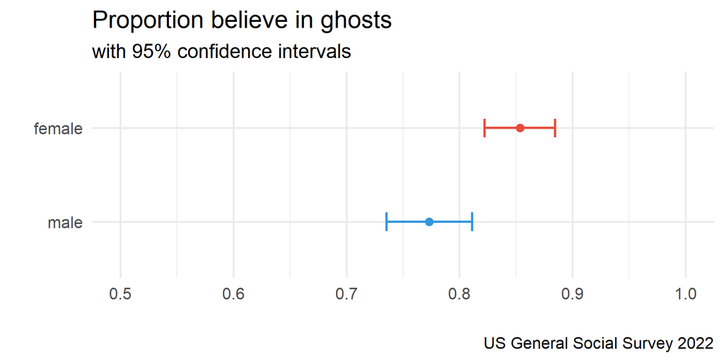

## Comparing CIs

- Code
- Table
- Plot

```r
df_wwwhr <- my_data |>
  group_by(sex) |>
  summarise(
    n = n(),
    mean = mean(wwwhr),
    sd = sd(wwwhr),
    lower = CI(wwwhr, ci = 0.95)['lower'],
    upper  = CI(wwwhr, ci = 0.95)['upper']
    )
```

```r
df_wwwhr
```

```
# A tibble: 2 × 6
  sex        n  mean    sd lower upper
  <fct>  <int> <dbl> <dbl> <dbl> <dbl>
1 male     472  16.2  19.8  14.4  17.9
2 female   498  19.1  24.4  16.9  21.2
```

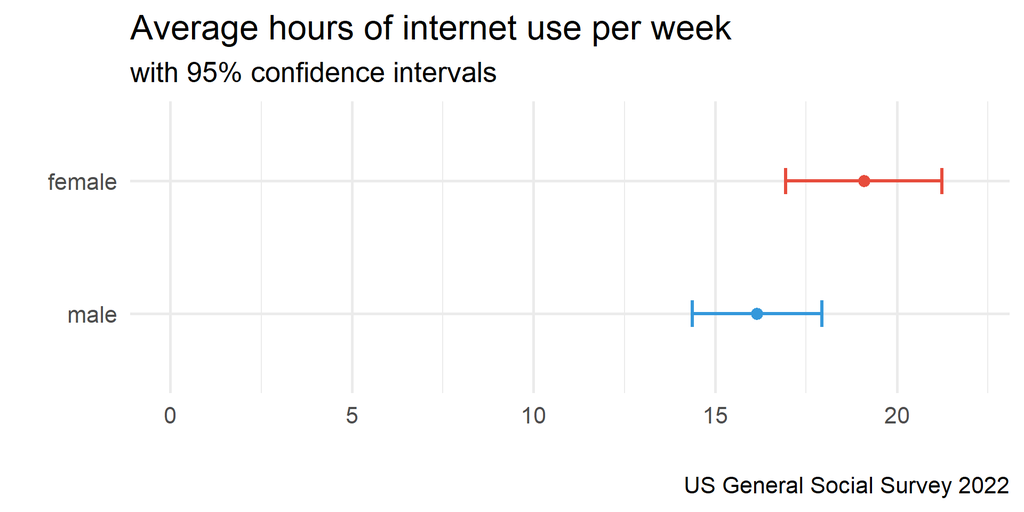

# Hypothesis Testing

## `t.test()`

Performs one and two sample t-tests. To use this function, we’ll need to specify a few things:

- variable of interest
- mu (H0): a number indicating the true value of the mean
- alternative hypothesis (H1): “two.sided”, “greater”, or “less”

## `t.test()` in action

In your family sociology course you learned that fertility rates have been dropping.

You used to think that people had 2 children, on average. But, now you suspect that people are having fewer than 2 children.

How do you test your hypothesis?

Which of these equations represents your **research** hypothesis?

- H1: µ ≠ 2
- H1: µ = 2
- H1: µ < 2
- H1: µ > 2

Which of these equations represents your **null** hypothesis?

- H0: µ ≠ 2
- H0: µ = 2
- H0: µ < 2
- H0: µ > 2

## Review: Summary Statistics

```r
my_data |>
  summarise(
    n = n(),
    mean = mean(childs),
    median = median(childs),
    sd = sd(childs))
```

```
# A tibble: 1 × 4
      n  mean median    sd
  <int> <dbl>  <dbl> <dbl>
1   970  1.79      2  1.64
```

Is the difference between our sample mean and 2 statistically significant or could we have gotten this mean simply by chance (sample variation)?

## Review: CIs

```r
my_data |>
  summarise(
    n = n(),
    mean = mean(childs),
    median = median(childs),
    sd = sd(childs),
    se = sd / sqrt(n),
    lower = CI(childs, ci = 0.99)['lower'],
    upper  = CI(childs, ci = 0.99)['upper']
    )
```

```
# A tibble: 1 × 7
      n  mean median    sd     se lower upper
  <int> <dbl>  <dbl> <dbl>  <dbl> <dbl> <dbl>
1   970  1.79      2  1.64 0.0526  1.66  1.93
```

Does the confidence interval overlap with 2? What does that tell you?

## One sample `t.test()` for means

```r
t.test(my_data$childs)
```

```
    One Sample t-test

data:  my_data$childs
t = 34.102, df = 969, p-value < 2.2e-16
alternative hypothesis: true mean is not equal to 0
95 percent confidence interval:
 1.690587 1.897041
sample estimates:
mean of x
 1.793814
```

> **H0 = 0 by default**

## One sample `t.test()` for means

```r
t.test(my_data$childs, mu=2, alternative="less") # Ho: mu=2
```

```
    One Sample t-test

data:  my_data$childs
t = -3.9197, df = 969, p-value = 4.744e-05
alternative hypothesis: true mean is less than 2
95 percent confidence interval:
    -Inf 1.88042
sample estimates:
mean of x
 1.793814
```

> **H0 = 2; one-tail test**

Assuming an α level of .01, should you reject the null hypothesis?

- No, because the 𝛼 level of .01 is greater than the p-value (< .000).
- No, because the p-value (< .000) is less than the 𝛼 level of .01.
- Yes, because the p-value (< .000) is less than the 𝛼 level of .01.

Which of these statements best summarizes your conclusion?

- Our evidence proves that people have fewer than two children, on average.
- People, on average, have two children.
- On average, the number of children people have is statistically significantly lower than two.

## two sample `t.test()` in action

Are the proportions of men and women who believe in ghosts statistically significantly different?

```r
t.test(my_data$ghosts ~ my_data$sex, alternative = "two.sided")
```

```
    Welch Two Sample t-test

data:  my_data$ghosts by my_data$sex
t = -3.2072, df = 923.29, p-value = 0.001387
alternative hypothesis: true difference in means between group male and group female is not equal to 0
95 percent confidence interval:
 -0.1291289 -0.0310882
sample estimates:
  mean in group male mean in group female
           0.7733051            0.8534137
```

Assuming an α level of .05, what do you conclude?

- There is no statistically significant difference between men and women in belief in ghosts.
- Men are significantly more likely than women to believe in ghosts (p < .05).
- Women are significantly more likely than men to believe in ghosts (p < .05).

## Aside: paired `t.test()`

**Independent group t-test**  
Do two subsamples have the same mean?

```r
t.test(my_data$ghosts ~ my_data$sex, alternative = "two.sided")
```

**Paired t-test**  
Do two variables have the same mean?

```r
t.test(Pair(hrs1_2018, hrs1_2020) ~ 1, data = gss_panel)
```

# Think Like a Statistician

## Think Like a Statistician

**Do women have more years of education (`educ`) than men, on average?**

**Are the proportions of men & women who support abortion for any reason (`abany`) statistically different?**

**Do fewer men than women support gun laws (`gunlaw`)?**

Use the 2022 GSS dataset

## Think Like a Statistician

- `educ`
- `abany`
- `gunlaw`

```
    Welch Two Sample t-test

data:  gss22$educ by gss22$sex
t = -0.38076, df = 4035.7, p-value = 0.3517
alternative hypothesis: true difference in means between group 1 and group 2 is less than 0
95 percent confidence interval:
      -Inf 0.1144853
sample estimates:
mean in group 1 mean in group 2
       14.14338        14.17786
```

```
    Welch Two Sample t-test

data:  gss22$abany by gss22$sex
t = -1.0701, df = 1317.7, p-value = 0.2848
alternative hypothesis: true difference in means between group 1 and group 2 is not equal to 0
95 percent confidence interval:
 -0.08169512  0.02402811
sample estimates:
mean in group 1 mean in group 2
      0.5786164       0.6074499
```

```
    Welch Two Sample t-test

data:  gss22$gunlaw by gss22$sex
t = -8.9698, df = 2476.6, p-value < 2.2e-16
alternative hypothesis: true difference in means between group 1 and group 2 is not equal to 0
95 percent confidence interval:
 -0.1872801 -0.1200856
sample estimates:
mean in group 1 mean in group 2
      0.6450593       0.7987421
```

# Joining Dataframes (if time allows…)

## appending v.s. merging

**APPEND**

add new observations (rows) to existing variables

**MERGE**

add new variables (columns) to existing observations (many merge types)

## appending v.s. merging

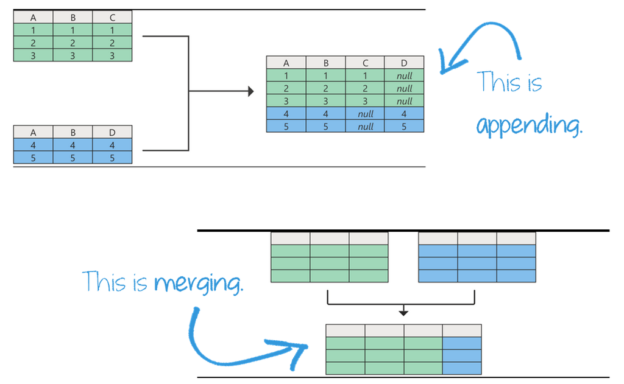

## Example datasets

**dataframe 1**

```
  coupleid  name age
1        2  John  42
2        1 Megan  36
3        3   Bin  38
```

**dataframe 2**

```
  coupleid    name age
1        1     Sue  40
2        3  Ye-jin  39
3        2 Chrissy  35
```

**dataframe 3**

```
  coupleid marstat numchild country
1        3       1        1 S.Korea
2        1       0        0      US
3        4       1        2  Canada
```

## append data with `bind_rows()`

```r
df_all <- bind_rows(df_partner1, df_partner2)

tibble(df_all)
```

```
# A tibble: 6 × 3
  coupleid name      age
     <dbl> <chr>   <dbl>
1        2 John       42
2        1 Megan      36
3        3 Bin        38
4        1 Sue        40
5        3 Ye-jin     39
6        2 Chrissy    35
```

## merge data with joins

add columns from `df1` to `df2`, matching observations based on the keys

- `left_join()` keeps all observations in `df1`.
- `right_join()` keeps all observations in `df2`.
- `full_join()` keeps all observations in `df1` and `df2`.
- `inner_join()` only keeps observations from `df1` that have a matching key in `df2`

## `left_join()`

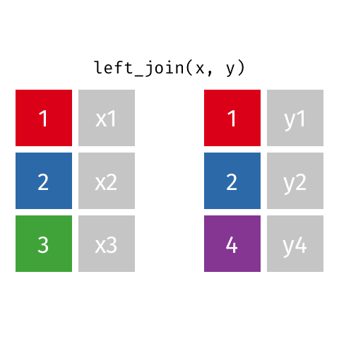

```r
df_couples <- left_join(df_partner1, df_family, by = "coupleid")

tibble(df_couples)
```

```
# A tibble: 3 × 6
  coupleid name    age marstat numchild country
     <dbl> <chr> <dbl>   <dbl>    <dbl> <chr>
1        2 John     42      NA       NA <NA>
2        1 Megan    36       0        0 US
3        3 Bin      38       1        1 S.Korea
```

## `right_join()`

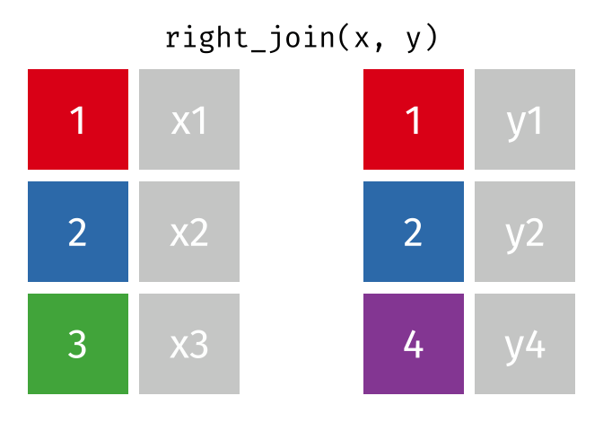

```r
df_couples <- right_join(df_partner1, df_family, by = "coupleid")

tibble(df_couples)
```

```
# A tibble: 3 × 6
  coupleid name    age marstat numchild country
     <dbl> <chr> <dbl>   <dbl>    <dbl> <chr>
1        1 Megan    36       0        0 US
2        3 Bin      38       1        1 S.Korea
3        4 <NA>     NA       1        2 Canada
```

## `full_join()`

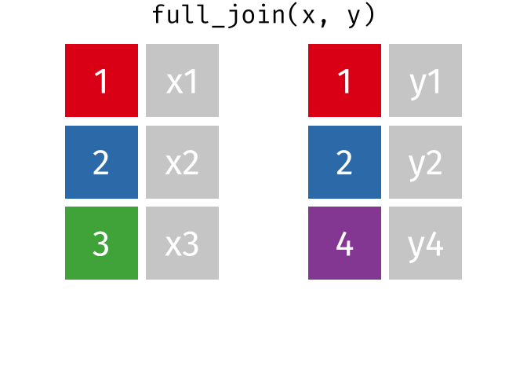

```r
df_couples <- full_join(df_partner1, df_family, by = "coupleid")

tibble(df_couples)
```

```
# A tibble: 4 × 6
  coupleid name    age marstat numchild country
     <dbl> <chr> <dbl>   <dbl>    <dbl> <chr>
1        2 John     42      NA       NA <NA>
2        1 Megan    36       0        0 US
3        3 Bin      38       1        1 S.Korea
4        4 <NA>     NA       1        2 Canada
```

## `inner_join()`

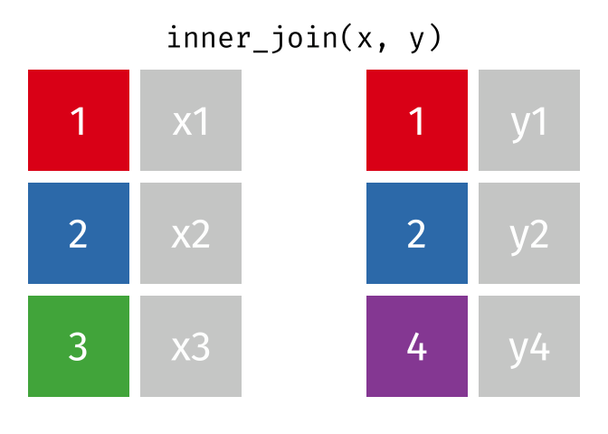

```r
df_couples <- inner_join(df_partner1, df_family, by = "coupleid")

tibble(df_couples)
```

```
# A tibble: 2 × 6
  coupleid name    age marstat numchild country
     <dbl> <chr> <dbl>   <dbl>    <dbl> <chr>
1        1 Megan    36       0        0 US
2        3 Bin      38       1        1 S.Korea
```